# FA2 DSC1107

Lindsay Faith Bazar

February 17, 2025

## 2. Import

```r
data("who")
data("population")
```

**2.1. Preview the contents of who.tsv and population.csv by inspecting the files.**

```r
head(who)
```

```
## # A tibble: 6 × 60
##   country   iso2  iso3   year new_sp_m014 new_sp_m1524 new_sp_m2534 new_sp_m3544
##   <chr>     <chr> <chr> <dbl>       <dbl>        <dbl>        <dbl>        <dbl>
## 1 Afghanis… AF    AFG    1980          NA           NA           NA           NA
## 2 Afghanis… AF    AFG    1981          NA           NA           NA           NA
## 3 Afghanis… AF    AFG    1982          NA           NA           NA           NA
## 4 Afghanis… AF    AFG    1983          NA           NA           NA           NA
## 5 Afghanis… AF    AFG    1984          NA           NA           NA           NA
## 6 Afghanis… AF    AFG    1985          NA           NA           NA           NA
## # ℹ 52 more variables: new_sp_m4554 <dbl>, new_sp_m5564 <dbl>,
## #   new_sp_m65 <dbl>, new_sp_f014 <dbl>, new_sp_f1524 <dbl>,
## #   new_sp_f2534 <dbl>, new_sp_f3544 <dbl>, new_sp_f4554 <dbl>,
## #   new_sp_f5564 <dbl>, new_sp_f65 <dbl>, new_sn_m014 <dbl>,
## #   new_sn_m1524 <dbl>, new_sn_m2534 <dbl>, new_sn_m3544 <dbl>,
## #   new_sn_m4554 <dbl>, new_sn_m5564 <dbl>, new_sn_m65 <dbl>,
## #   new_sn_f014 <dbl>, new_sn_f1524 <dbl>, new_sn_f2534 <dbl>, …
```

```r
head(population)
```

```
## # A tibble: 6 × 3
##   country      year population
##   <chr>       <dbl>      <dbl>
## 1 Afghanistan  1995   17586073
## 2 Afghanistan  1996   18415307
## 3 Afghanistan  1997   19021226
## 4 Afghanistan  1998   19496836
## 5 Afghanistan  1999   19987071
## 6 Afghanistan  2000   20595360
```

**2.2. Import the data into tibbles named who and population.**

```r
who <- as_tibble(who)
population <- as_tibble(population)
who
```

```
## # A tibble: 7,240 × 60
##    country  iso2  iso3   year new_sp_m014 new_sp_m1524 new_sp_m2534 new_sp_m3544
##    <chr>    <chr> <chr> <dbl>       <dbl>        <dbl>        <dbl>        <dbl>
##  1 Afghani… AF    AFG    1980          NA           NA           NA           NA
##  2 Afghani… AF    AFG    1981          NA           NA           NA           NA
##  3 Afghani… AF    AFG    1982          NA           NA           NA           NA
##  4 Afghani… AF    AFG    1983          NA           NA           NA           NA
##  5 Afghani… AF    AFG    1984          NA           NA           NA           NA
##  6 Afghani… AF    AFG    1985          NA           NA           NA           NA
##  7 Afghani… AF    AFG    1986          NA           NA           NA           NA
##  8 Afghani… AF    AFG    1987          NA           NA           NA           NA
##  9 Afghani… AF    AFG    1988          NA           NA           NA           NA
## 10 Afghani… AF    AFG    1989          NA           NA           NA           NA
## # ℹ 7,230 more rows
## # ℹ 52 more variables: new_sp_m4554 <dbl>, new_sp_m5564 <dbl>,
## #   new_sp_m65 <dbl>, new_sp_f014 <dbl>, new_sp_f1524 <dbl>,
## #   new_sp_f2534 <dbl>, new_sp_f3544 <dbl>, new_sp_f4554 <dbl>,
## #   new_sp_f5564 <dbl>, new_sp_f65 <dbl>, new_sn_m014 <dbl>,
## #   new_sn_m1524 <dbl>, new_sn_m2534 <dbl>, new_sn_m3544 <dbl>,
## #   new_sn_m4554 <dbl>, new_sn_m5564 <dbl>, new_sn_m65 <dbl>, …
```

```r
population
```

```
## # A tibble: 4,060 × 3
##    country      year population
##    <chr>       <dbl>      <dbl>
##  1 Afghanistan  1995   17586073
##  2 Afghanistan  1996   18415307
##  3 Afghanistan  1997   19021226
##  4 Afghanistan  1998   19496836
##  5 Afghanistan  1999   19987071
##  6 Afghanistan  2000   20595360
##  7 Afghanistan  2001   21347782
##  8 Afghanistan  2002   22202806
##  9 Afghanistan  2003   23116142
## 10 Afghanistan  2004   24018682
## # ℹ 4,050 more rows
```

**2.3. Determine the number of rows and columns in each tibble.**

```r
dim(who)
```

```
## [1] 7240   60
```

```r
dim(population)
```

```
## [1] 4060    3
```

**2.4. Check the summary of variable types for population.csv. Fix any anomalies and store the corrected data in population2.**

```r
summary(population)
```

```
##    country               year        population
##  Length:4060        Min.   :1995   Min.   :1.129e+03
##  Class :character   1st Qu.:1999   1st Qu.:6.029e+05
##  Mode  :character   Median :2004   Median :5.319e+06
##                     Mean   :2004   Mean   :3.003e+07
##                     3rd Qu.:2009   3rd Qu.:1.855e+07
##                     Max.   :2013   Max.   :1.386e+09
```

```r
population2 <- population
population2
```

```
## # A tibble: 4,060 × 3
##    country      year population
##    <chr>       <dbl>      <dbl>
##  1 Afghanistan  1995   17586073
##  2 Afghanistan  1996   18415307
##  3 Afghanistan  1997   19021226
##  4 Afghanistan  1998   19496836
##  5 Afghanistan  1999   19987071
##  6 Afghanistan  2000   20595360
##  7 Afghanistan  2001   21347782
##  8 Afghanistan  2002   22202806
##  9 Afghanistan  2003   23116142
## 10 Afghanistan  2004   24018682
## # ℹ 4,050 more rows
```

## 3. Tidy Data

**3.1.1 Identify the variables in the dataset.**

```r
colnames(who)
```

```
##  [1] "country"      "iso2"         "iso3"         "year"         "new_sp_m014"
##  [6] "new_sp_m1524" "new_sp_m2534" "new_sp_m3544" "new_sp_m4554" "new_sp_m5564"
## [11] "new_sp_m65"   "new_sp_f014"  "new_sp_f1524" "new_sp_f2534" "new_sp_f3544"
## [16] "new_sp_f4554" "new_sp_f5564" "new_sp_f65"   "new_sn_m014"  "new_sn_m1524"
## [21] "new_sn_m2534" "new_sn_m3544" "new_sn_m4554" "new_sn_m5564" "new_sn_m65"
## [26] "new_sn_f014"  "new_sn_f1524" "new_sn_f2534" "new_sn_f3544" "new_sn_f4554"
## [31] "new_sn_f5564" "new_sn_f65"   "new_ep_m014"  "new_ep_m1524" "new_ep_m2534"
## [36] "new_ep_m3544" "new_ep_m4554" "new_ep_m5564" "new_ep_m65"   "new_ep_f014"
## [41] "new_ep_f1524" "new_ep_f2534" "new_ep_f3544" "new_ep_f4554" "new_ep_f5564"
## [46] "new_ep_f65"   "newrel_m014"  "newrel_m1524" "newrel_m2534" "newrel_m3544"
## [51] "newrel_m4554" "newrel_m5564" "newrel_m65"   "newrel_f014"  "newrel_f1524"
## [56] "newrel_f2534" "newrel_f3544" "newrel_f4554" "newrel_f5564" "newrel_f65"
```

**3.1.2 Perform a pivot operation to make the data tidy, storing the result in who2.**

```r
who2 <- who %>%
  pivot_longer(
    cols = -c(country, iso2, iso3, year),
    names_to = c("new", "TB_Type", "gender_age"),
    names_pattern = "^(newrel|new)_(sn|sp|ep|rel)?_?(m\\d+|f\\d+)?$",
    values_to = "count"
  ) %>%
  mutate(TB_Type = ifelse(TB_Type == "" | is.na(TB_Type), "rel", TB_Type))

who2
```

```
## # A tibble: 405,440 × 8
##    country     iso2  iso3   year new   TB_Type gender_age count
##    <chr>       <chr> <chr> <dbl> <chr> <chr>   <chr>      <dbl>
##  1 Afghanistan AF    AFG    1980 new   sp      m014          NA
##  2 Afghanistan AF    AFG    1980 new   sp      m1524         NA
##  3 Afghanistan AF    AFG    1980 new   sp      m2534         NA
##  4 Afghanistan AF    AFG    1980 new   sp      m3544         NA
##  5 Afghanistan AF    AFG    1980 new   sp      m4554         NA
##  6 Afghanistan AF    AFG    1980 new   sp      m5564         NA
##  7 Afghanistan AF    AFG    1980 new   sp      m65           NA
##  8 Afghanistan AF    AFG    1980 new   sp      f014          NA
##  9 Afghanistan AF    AFG    1980 new   sp      f1524         NA
## 10 Afghanistan AF    AFG    1980 new   sp      f2534         NA
## # ℹ 405,430 more rows
```

**3.1.3 Separate values like new_ep_f014 into components (e.g., new, ep, f014). Remove the column containing new, and store the result in who3.**

```r
who3 <- who2 %>%
  select(-new)

who3
```

```
## # A tibble: 405,440 × 7
##    country     iso2  iso3   year TB_Type gender_age count
##    <chr>       <chr> <chr> <dbl> <chr>   <chr>      <dbl>
##  1 Afghanistan AF    AFG    1980 sp      m014          NA
##  2 Afghanistan AF    AFG    1980 sp      m1524         NA
##  3 Afghanistan AF    AFG    1980 sp      m2534         NA
##  4 Afghanistan AF    AFG    1980 sp      m3544         NA
##  5 Afghanistan AF    AFG    1980 sp      m4554         NA
##  6 Afghanistan AF    AFG    1980 sp      m5564         NA
##  7 Afghanistan AF    AFG    1980 sp      m65           NA
##  8 Afghanistan AF    AFG    1980 sp      f014          NA
##  9 Afghanistan AF    AFG    1980 sp      f1524         NA
## 10 Afghanistan AF    AFG    1980 sp      f2534         NA
## # ℹ 405,430 more rows
```

**3.1.4 Further separate values like f014 into f and 014, storing the result in who_tidy.**

```r
who_tidy <- who3 %>%
  separate(col = gender_age, into = c("gender", "age"), sep = "(?<=^[mf])")

who_tidy
```

```
## # A tibble: 405,440 × 8
##    country     iso2  iso3   year TB_Type gender age   count
##    <chr>       <chr> <chr> <dbl> <chr>   <chr>  <chr> <dbl>
##  1 Afghanistan AF    AFG    1980 sp      m      014      NA
##  2 Afghanistan AF    AFG    1980 sp      m      1524     NA
##  3 Afghanistan AF    AFG    1980 sp      m      2534     NA
##  4 Afghanistan AF    AFG    1980 sp      m      3544     NA
##  5 Afghanistan AF    AFG    1980 sp      m      4554     NA
##  6 Afghanistan AF    AFG    1980 sp      m      5564     NA
##  7 Afghanistan AF    AFG    1980 sp      m      65       NA
##  8 Afghanistan AF    AFG    1980 sp      f      014      NA
##  9 Afghanistan AF    AFG    1980 sp      f      1524     NA
## 10 Afghanistan AF    AFG    1980 sp      f      2534     NA
## # ℹ 405,430 more rows
```

**3.2.1 Identify the variables in this dataset.**

```r
colnames(population2)
```

```
## [1] "country"    "year"       "population"
```

**3.2.2 Perform a pivot operation to tidy the data, storing the result in population3.**

The dataset looks already in a tidy format, where each row represents a unique observation with country, year, and population so we need not do pivot operation.

```r
population2
```

```
## # A tibble: 4,060 × 3
##    country      year population
##    <chr>       <dbl>      <dbl>
##  1 Afghanistan  1995   17586073
##  2 Afghanistan  1996   18415307
##  3 Afghanistan  1997   19021226
##  4 Afghanistan  1998   19496836
##  5 Afghanistan  1999   19987071
##  6 Afghanistan  2000   20595360
##  7 Afghanistan  2001   21347782
##  8 Afghanistan  2002   22202806
##  9 Afghanistan  2003   23116142
## 10 Afghanistan  2004   24018682
## # ℹ 4,050 more rows
```

```r
population3 <- population2
```

**3.2.3 Cast the population variable to an appropriate data type, storing the result in population_tidy.**

```r
population_tidy<-population2 %>%
  mutate(population= as.integer(population))

population_tidy
```

```
## # A tibble: 4,060 × 3
##    country      year population
##    <chr>       <dbl>      <int>
##  1 Afghanistan  1995   17586073
##  2 Afghanistan  1996   18415307
##  3 Afghanistan  1997   19021226
##  4 Afghanistan  1998   19496836
##  5 Afghanistan  1999   19987071
##  6 Afghanistan  2000   20595360
##  7 Afghanistan  2001   21347782
##  8 Afghanistan  2002   22202806
##  9 Afghanistan  2003   23116142
## 10 Afghanistan  2004   24018682
## # ℹ 4,050 more rows
```

## 3.3. Join Datasets

```r
tuberculosis<-population_tidy %>%
  left_join(who_tidy, by=c("country", "year"))
tuberculosis<-tuberculosis %>%
  mutate(count=as.integer(count))

tuberculosis
```

```
## # A tibble: 226,095 × 9
##    country      year population iso2  iso3  TB_Type gender age   count
##    <chr>       <dbl>      <int> <chr> <chr> <chr>   <chr>  <chr> <int>
##  1 Afghanistan  1995   17586073 AF    AFG   sp      m      014      NA
##  2 Afghanistan  1995   17586073 AF    AFG   sp      m      1524     NA
##  3 Afghanistan  1995   17586073 AF    AFG   sp      m      2534     NA
##  4 Afghanistan  1995   17586073 AF    AFG   sp      m      3544     NA
##  5 Afghanistan  1995   17586073 AF    AFG   sp      m      4554     NA
##  6 Afghanistan  1995   17586073 AF    AFG   sp      m      5564     NA
##  7 Afghanistan  1995   17586073 AF    AFG   sp      m      65       NA
##  8 Afghanistan  1995   17586073 AF    AFG   sp      f      014      NA
##  9 Afghanistan  1995   17586073 AF    AFG   sp      f      1524     NA
## 10 Afghanistan  1995   17586073 AF    AFG   sp      f      2534     NA
## # ℹ 226,085 more rows
```

```r
colnames(tuberculosis)
```

```
## [1] "country"    "year"       "population" "iso2"       "iso3"
## [6] "TB_Type"    "gender"     "age"        "count"
```

## 3.4. Clean up Data

**3.4.1 Remove unnecessary variables from tuberculosis.**

```r
tuberculosis2 <- tuberculosis %>% select(-iso2, -iso3)
tuberculosis2
```

```
## # A tibble: 226,095 × 7
##    country      year population TB_Type gender age   count
##    <chr>       <dbl>      <int> <chr>   <chr>  <chr> <int>
##  1 Afghanistan  1995   17586073 sp      m      014      NA
##  2 Afghanistan  1995   17586073 sp      m      1524     NA
##  3 Afghanistan  1995   17586073 sp      m      2534     NA
##  4 Afghanistan  1995   17586073 sp      m      3544     NA
##  5 Afghanistan  1995   17586073 sp      m      4554     NA
##  6 Afghanistan  1995   17586073 sp      m      5564     NA
##  7 Afghanistan  1995   17586073 sp      m      65       NA
##  8 Afghanistan  1995   17586073 sp      f      014      NA
##  9 Afghanistan  1995   17586073 sp      f      1524     NA
## 10 Afghanistan  1995   17586073 sp      f      2534     NA
## # ℹ 226,085 more rows
```

**3.4.2 Filter out rows with NA values.**

```r
tuberculosis3 <- tuberculosis2 %>% drop_na()
tuberculosis3
```

```
## # A tibble: 75,234 × 7
##    country      year population TB_Type gender age   count
##    <chr>       <dbl>      <int> <chr>   <chr>  <chr> <int>
##  1 Afghanistan  1997   19021226 sp      m      014       0
##  2 Afghanistan  1997   19021226 sp      m      1524     10
##  3 Afghanistan  1997   19021226 sp      m      2534      6
##  4 Afghanistan  1997   19021226 sp      m      3544      3
##  5 Afghanistan  1997   19021226 sp      m      4554      5
##  6 Afghanistan  1997   19021226 sp      m      5564      2
##  7 Afghanistan  1997   19021226 sp      m      65        0
##  8 Afghanistan  1997   19021226 sp      f      014       5
##  9 Afghanistan  1997   19021226 sp      f      1524     38
## 10 Afghanistan  1997   19021226 sp      f      2534     36
## # ℹ 75,224 more rows
```

**3.4.3 Save the cleaned data back into tuberculosis.**

```r
tuberculosis <- tuberculosis3
tuberculosis
```

```
## # A tibble: 75,234 × 7
##    country      year population TB_Type gender age   count
##    <chr>       <dbl>      <int> <chr>   <chr>  <chr> <int>
##  1 Afghanistan  1997   19021226 sp      m      014       0
##  2 Afghanistan  1997   19021226 sp      m      1524     10
##  3 Afghanistan  1997   19021226 sp      m      2534      6
##  4 Afghanistan  1997   19021226 sp      m      3544      3
##  5 Afghanistan  1997   19021226 sp      m      4554      5
##  6 Afghanistan  1997   19021226 sp      m      5564      2
##  7 Afghanistan  1997   19021226 sp      m      65        0
##  8 Afghanistan  1997   19021226 sp      f      014       5
##  9 Afghanistan  1997   19021226 sp      f      1524     38
## 10 Afghanistan  1997   19021226 sp      f      2534     36
## # ℹ 75,224 more rows
```

## Data Manipulation

**4.1 Determine the total TB cases among men and women in the 21st century in the United States. Identify which sex had more cases.**

```r
USA <- tuberculosis %>%
  filter(str_detect(country, "United States of America"), year >= 2001) %>%
  group_by(gender) %>%
  summarise(total_cases = sum(count, na.rm = TRUE), .groups = "drop")


USA <- USA %>%
  bind_rows(tibble(gender = "Total", total_cases = sum(USA$total_cases, na.rm = TRUE)))

print(USA)
```

```
## # A tibble: 3 × 2
##   gender total_cases
##   <chr>        <int>
## 1 f            43982
## 2 m            73769
## 3 Total       117751
```

In the 21st century in the U.S.A., men had 73,769 TB cases, while women had 43,982. That’s 29,787 more cases in men, making them the most affected group. The total number of cases for both genders combined was 117,751.

**4.2 Create a new variable, cases_per_100k, representing TB cases per 100,000 people by year, sex, age group, and TB type.**

```r
tuberculosis <- tuberculosis %>%
  mutate(cases_per_100k = (count / population) * 100000)
tuberculosis
```

```
## # A tibble: 75,234 × 8
##    country      year population TB_Type gender age   count cases_per_100k
##    <chr>       <dbl>      <int> <chr>   <chr>  <chr> <int>          <dbl>
##  1 Afghanistan  1997   19021226 sp      m      014       0         0
##  2 Afghanistan  1997   19021226 sp      m      1524     10         0.0526
##  3 Afghanistan  1997   19021226 sp      m      2534      6         0.0315
##  4 Afghanistan  1997   19021226 sp      m      3544      3         0.0158
##  5 Afghanistan  1997   19021226 sp      m      4554      5         0.0263
##  6 Afghanistan  1997   19021226 sp      m      5564      2         0.0105
##  7 Afghanistan  1997   19021226 sp      m      65        0         0
##  8 Afghanistan  1997   19021226 sp      f      014       5         0.0263
##  9 Afghanistan  1997   19021226 sp      f      1524     38         0.200
## 10 Afghanistan  1997   19021226 sp      f      2534     36         0.189
## # ℹ 75,224 more rows
```

**4.3 Identify:**

**The country and year with the highest cases per 100k.**

```r
highest_cases <- tuberculosis %>%
  filter(!is.na(cases_per_100k)) %>%
  arrange(desc(cases_per_100k)) %>%
  slice(1) %>%
  select(country, year, cases_per_100k)

print(highest_cases)
```

```
## # A tibble: 1 × 3
##   country  year cases_per_100k
##   <chr>   <dbl>          <dbl>
## 1 Samoa    2009           602.
```

The country that are recorded to have the highest tuberculosis case per 100,000 people (602. cases) is the country Samoa in the year 2009.

**The country and year with the lowest cases per 100k.**

```r
lowest_cases <- tuberculosis %>%
  filter(!is.na(cases_per_100k)) %>%
  arrange(cases_per_100k) %>%
  slice(1) %>%
  select(country, year, cases_per_100k)

print(lowest_cases)
```

```
## # A tibble: 1 × 3
##   country      year cases_per_100k
##   <chr>       <dbl>          <dbl>
## 1 Afghanistan  1997              0
```

While the country with lowest case of tuberculosis is Afghanistan (no case) in the year 1997.

## Data Visualization

**5.1 Plot the total cases per 100k as a function of year for China, India, and the United States: Use a log scale on the y-axis (scale_y_log10()).Describe emerging patterns**

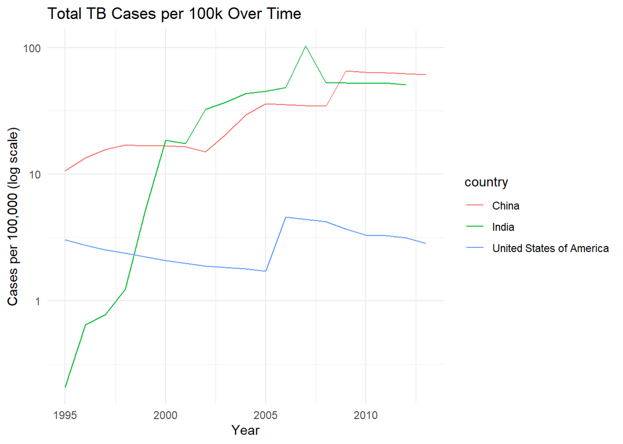

```r
library(ggplot2)

tuberculosis %>%
  filter(country %in% c("China", "India", "United States of America")) %>%
  group_by(country, year) %>%
  summarise(total_per_100k = sum(cases_per_100k, na.rm = TRUE), .groups = "drop") %>%
  ggplot(aes(x = year, y = total_per_100k, color = country)) +
  geom_line() +
  scale_y_log10() +
  labs(title = "Total TB Cases per 100k Over Time",
       x = "Year",
       y = "Cases per 100,000 (log scale)") +
  theme_minimal()
```

The TB trends look different for each country. In the U.S. (blue line), TB cases stayed low, with a small increase around 2005 but mostly declining over time. In China (red line), cases went up steadily until about 2008 that it leveled off. India (green line) saw a sharp rise in cases from 1995 to the early 2000s, peaking around 2007, then decreases and leveled off. This suggests that India and China had big TB outbreaks before things started to stabilize, while the U.S. had some few rises, but in general kept TB cases low.

**5.2 Compare distributions of total cases per 100k (summed over years, sexes, and TB types) across age groups: Use a log scale on the y-axis. Highlight observed patterns.**

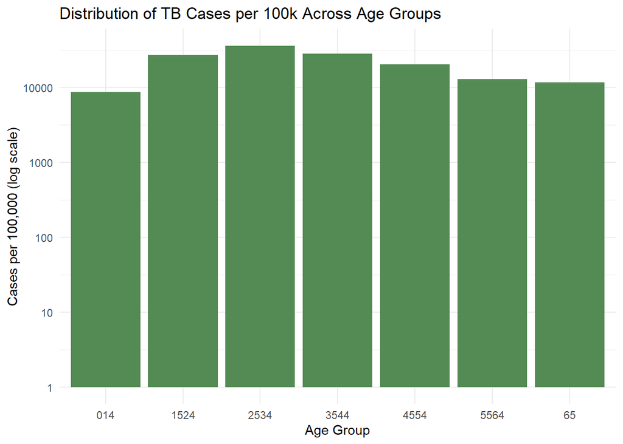

```r
tuberculosis %>%
  group_by(age) %>%
  summarise(total_per_100k = sum(cases_per_100k, na.rm = TRUE), .groups = "drop") %>%
  ggplot(aes(x = age, y = total_per_100k)) +
  geom_bar(stat = "identity", fill = "palegreen4") +
  scale_y_log10() +
  labs(title = "Distribution of TB Cases per 100k Across Age Groups",
       x = "Age Group",
       y = "Cases per 100,000 (log scale)") +
  theme_minimal()
```

TB cases are lowest among children (0-14 years old) and highest among adults aged 25-34. This pattern may be because this age are at their working years which may be more exposed to TB, possibly due to more social interactions and exposure. After that age group, the cases slowly decrease but still relatively high among seniors (65+).

**5.3 Create a plot to evaluate whether the number of cases per 100k in 2000 was related to a country’s population: Conclude based on the visualization.**

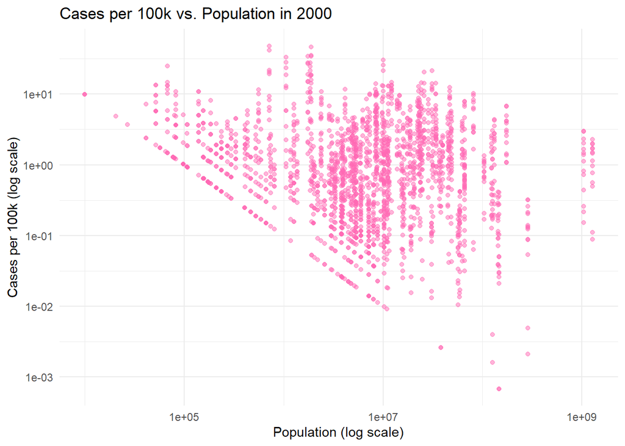

```r
tuberculosis %>%
  filter(year == 2000, cases_per_100k > 0, population > 0) %>%
  ggplot(aes(x = population, y = cases_per_100k)) +
  geom_point(alpha = 0.5, color = "hotpink") +
  scale_x_log10() +
  scale_y_log10() +
  labs(
    title = "Cases per 100k vs. Population in 2000",
    x = "Population (log scale)",
    y = "Cases per 100k (log scale)"
  ) +
  theme_minimal()
```